# Tomey Lab 4 Assignment - Landcover

## Challenge 5 (4 points)

**Use the voss2d() function to simulate 9 surfaces. In each one, g should be 7, but vary the value of H from 0.1 to 0.9. Create a unique landscape from each of these with a threshold value of 30% cover. Again, the 1 values can represent anything you desire, and again I suggest you set the seed for your simulation value so that you get the same outcome each time you run the code. Plot these landscapes.**

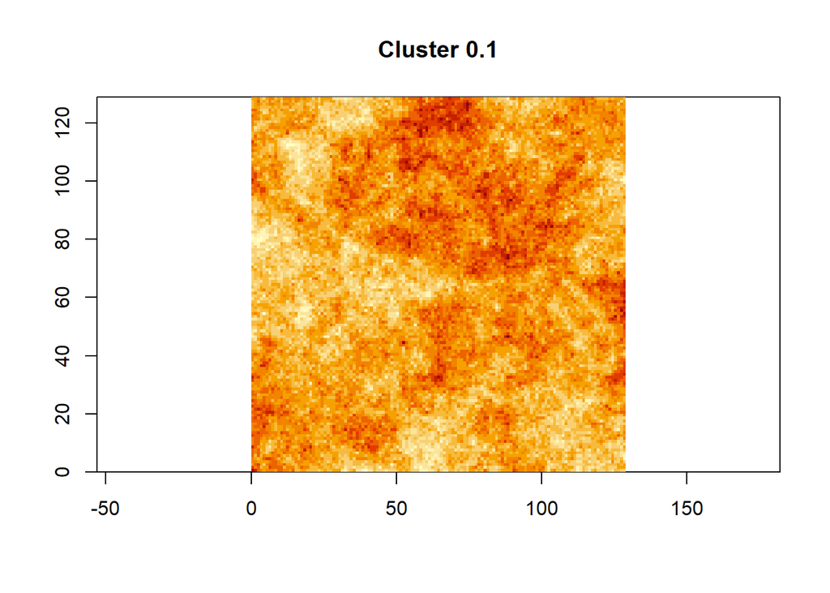

```r
set.seed(23)

# 1
voss1 = voss2d(g = 7, H = 0.1)
voss1 = rast(voss1$z)
image(voss1, main = "Cluster 0.1")
```

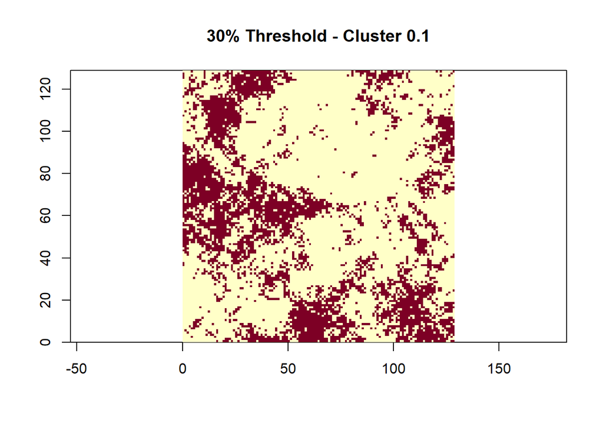

```r
thresholdv1 = quantile(as.matrix(voss1), prob = 0.3)
vossC1 = ifel(voss1 > thresholdv1, 0, 1)
image(vossC1, main = "30% Threshold - Cluster 0.1")
```

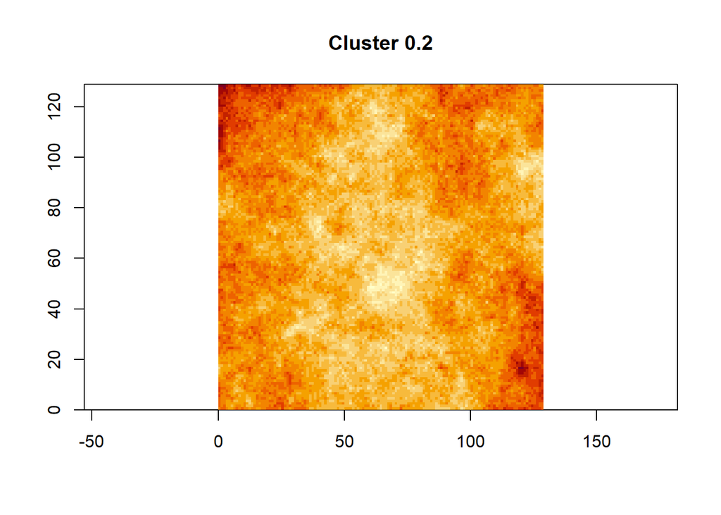

```r
# 2
voss2 = voss2d(g = 7, H = 0.2)
voss2 = rast(voss2$z)
image(voss2, main = "Cluster 0.2")
```